# Imprecision, information and weight of evidence

## Balance vs. weight

### Precursors

- Beans from a bag, two colors, same observed proportion, different sample sizes (C. S. Peirce, 1872).
- The notion of weight: balance might remain the same while the amount of relevant evidence shifts (Keynes 1921).

### Desiderata

- **Balance undetermination** Different weight with the same balance are possible.
- **Weak (strong) increase** In Bernoulli trials, weight does not decrease (increases) with sample size keeping frequency fixed.
- **Frequency monotonicity** In Bernoulli trials, keeping sample size fixed, weight does not decrease as observed frequency goes further from .5.

## No **unrestricted monotonicity**

### Weatherson, Joyce, Runde

- Straight flush has the probability of \(\frac{40}{2,958,960}\).
- The player starts behaving confusingly and bluffing.

## Weight and precise probablism

### Hamer’s certainty

Hamer’s absolute distance from 1 or 0 depending on the balance fails at **Balance undetermination**.

### Good’s desiderata and weight

- \(W(H:E)\) is some function of \(\mathsf{P}(E\vert H), \mathsf{P}(E\vert \neg H)\)
- \(\mathsf{P}(H \vert E) = g[W(H:e), \mathsf{P}(H)]\)
- \(W(H: E_1 \wedge E_2) = W(H:E_1) + W(H:E_2 \vert E_1)\)

\[W(H:E) = \log \frac{\mathsf{P}(E \vert H)}{\mathsf{P}(E\vert \neg H)}\]

## Good’s weight is not what we’re after

### Good’s own example (expanded)

- a die is selected at random from nine fair dice and one with bias \(\frac{1}{3}\).
- Uniform prior gives you weight of evidence for the loaded die \(log_{10}(.1)\), that is -1 (-10 db).
- Every time you toss it and obtain a six, you gain \(log_{10}(\frac{\frac{1}{3}}{\frac{1}{6}})= log_{10}(2)\)
- Every time you toss it and obtain something else, the weight changes by \(log_{10}(\frac{\frac{2}{3}}{\frac{5}{6}})= log_{10}(.8)\).

## Good’s weight fails at weak increase

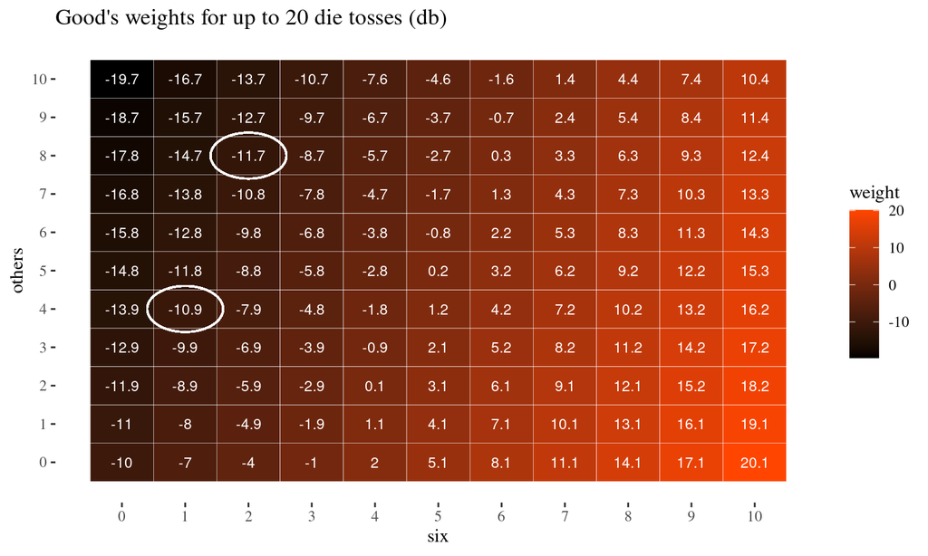

## Intervals

### Kyburg’s Evidential Probability

\(\mathsf{EP}(H \vert E \wedge K) = [x,y]\)

- Sharpening by richness (prefer frequencies from full joint distributions)
- Sharpening by specificity (prefer proper subsets)
- Sharpening by precision (pick single subinterval if it exists, otherwise, shortest possible cover of minimal subintervals)

### Pedden’s weight

Let \(\mathsf{EP}(H \vert E \wedge K) = [x,y]\), then:

\(\mathsf{WK(H\vert E\wedge K)} = 1 - (y-x)\).

## Troubles with EP

- Pedden picks edges by error margins (sensitivity!)
- Also, sensitivity to what happens around the edges only.
- How to deploy outside of combinatorial or frequentist contexts?
- Reasoning with intervals hard to model sensibly (does not preserve structural information)

## Imprecise probabilities

### Challenges to precise probabilism

- insufficient responsiveness to evidence
- fails to model indifference as sensitive to sweetening
- can’t distinguish between lack of knowledge and knowledge that \(\mathsf{P}(X)=.5\)
- trouble with aggregation methods (independence preservation etc.)

### Representor with pointwise Bayesian learning

\(\mathbb{P}_{t_1} = \{\mathsf{P}_{t_1}\vert \exists\, {\mathsf{P}_{t_0} \!\in \mathbb{P}_{t_0}}\,\, \forall\, {H}\,\, \left[\mathsf{P}_{t_1}(H)=\mathsf{P}_{t_0}(H \vert E)\right] \}\)

**Joyce:** \(w(X,E) = \sum_x \vert c(ch(X) = x \vert E) \times (x - c(X\vert E))^2 - c(ch(X) = x) \times (x - c(X))^2\vert\)

[output not shown]

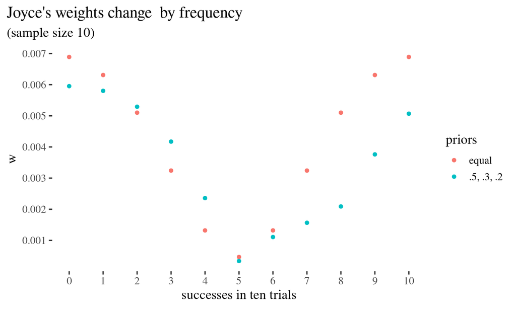

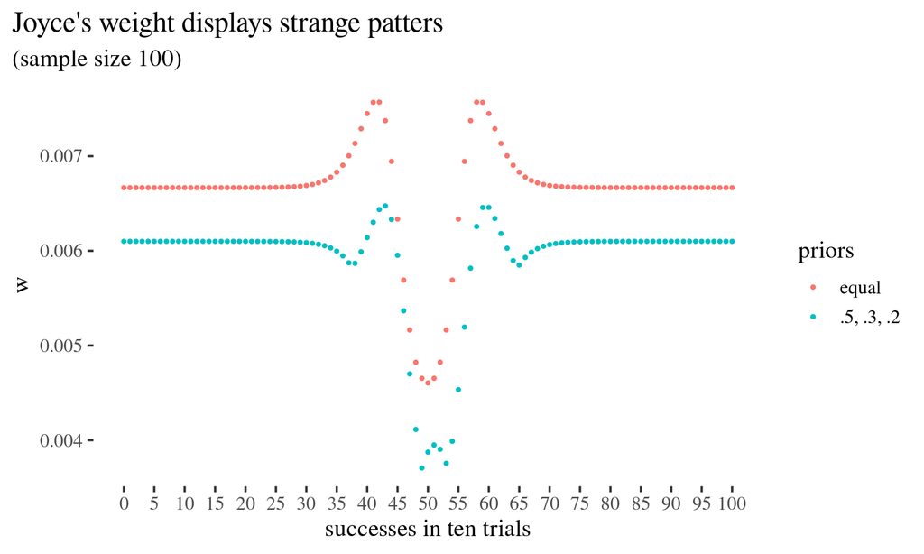

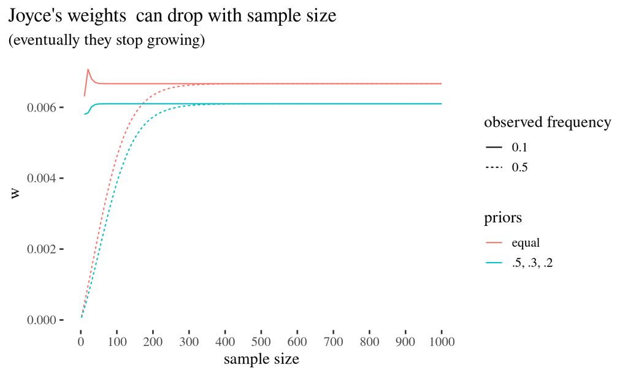

## Problems with Joyce’s weight

- Unintuitive behavior around chance hypotheses
- Failure of weak increase
- no real use of representors
- need to use of distributions over chance hypotheses
- taking credence to be the expected value is non-trivial

## General problems with IP

### Still not evidence sensitive

You still need to go higher-order to model some cases (e.g. uneven bias).

### Belief inertia

Point-wise updating can’t make you leave the set of all possible measures.

### Unclear mechanism of evidential constraints

- “Drop measures excluded by the evidence”. But how (other than degenerate cases)?
- How exactly does non-testimonial evidence of chances \(\{ \mathsf{P}(X) = x\}\) or \(\mathsf{P}(X) \in [x,y]\) is supposed to arise?

## General problems with IP

### Proper scoring rule is impossible

See results by Seidenfeld 2012, Mayo-Wilson 2016, Schoenfield 2017, Cambell-Moore 2020

### Aggregating doesn’t fly far

- Taking unions leads to skepticism. What else?
- Can’t model synergy

## Second-order approach to uncertainty

### Key idea

Often, uncertainty is not a single-dimensional thing to be mapped on a single one-dimensional scale such as a real line. It is the whole shape of the whole distribution over parameter values that should be taken under consideration. Summaries are just that.

## Some simple examples

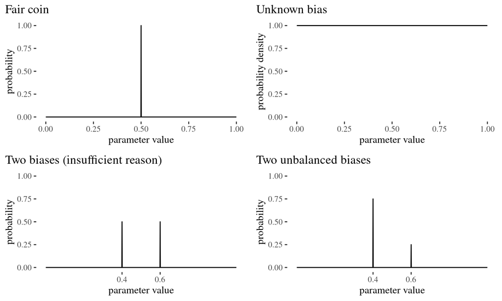

## Dealing with problems for IP

- Much more evidence sensitive (and can go higher order if needed).
- Seamless integration with Bayesian statistics explains learning.
- Belief inertia does not arise.
- HPDI comparison avoids Rinard’s objection.
- There is a proper scoring rule (Urbaniak 2022).
- Evidence-based aggregation is accuracy-wise better than averaging and can model synergy.

## Information theory crash-course

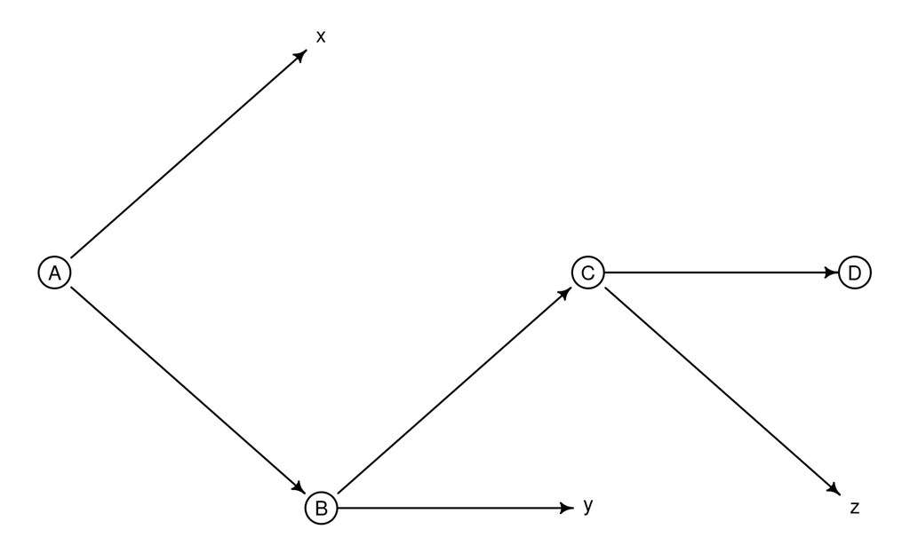

\[H(X) = \sum \mathsf{P}(x_i) \log_2 \frac{1}{\mathsf{P}(x_i)} = - \sum \mathsf{P}(x_i) \log_2 \mathsf{P}(x_i)\]

(the expected amount of information you receive once you learn what the value of \(X\) is).

## Cross-entropy and KLD

Say events arise according to a distribution \(\mathsf{P}\) but we predict them using a distribution \(\mathsf{Q}\).

### Kullback-Leibler divergence

\[\mathsf{KLD}(\mathsf{P}, \mathsf{Q}) = H(\mathsf{P}, \mathsf{Q}) - H(\mathsf{P})\\ = - \sum \mathsf{P}_i \log_2(\mathsf{Q}_i) - \left( - \sum \mathsf{P}_i \log_2 \mathsf{P}_i\right) \\ = - \sum \mathsf{P}_i\left( \log_2 \mathsf{Q}_i - \log_2\mathsf{P}_i\right)\\ = \sum \mathsf{P}_i\left( \log_2 \mathsf{P}_i - \log_2\mathsf{Q}_i\right)\\ = \sum \mathsf{P}_i \log_2 \left( \frac{\mathsf{P}_i}{\mathsf{Q_i}}\right) \]

## Weight of a distribution

### Key idea

The more informative a piece of evidence is, as compared to the uniform distribution, the more weight it has, on scale 0 to 1

\[\mathsf{w(P_i)} = 1 - \left( \frac{H(\mathsf{P})}{H(\mathsf{uniform})}\right)\]

## Weight of a distribution

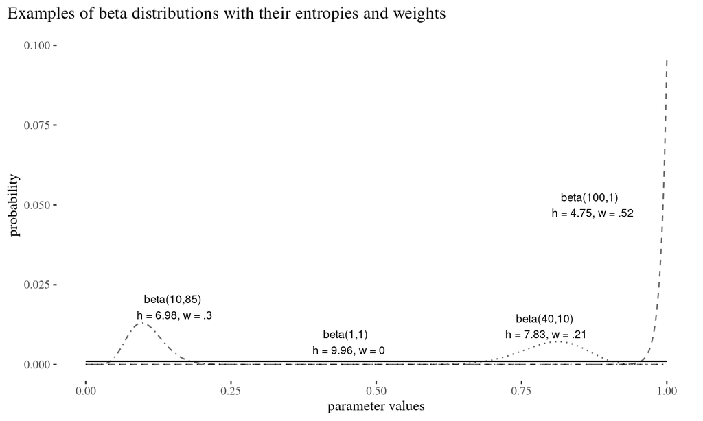

## Weak increase holds

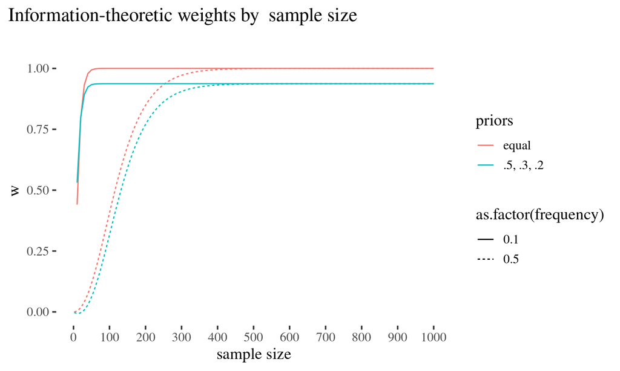

## Works for a variety of shapes

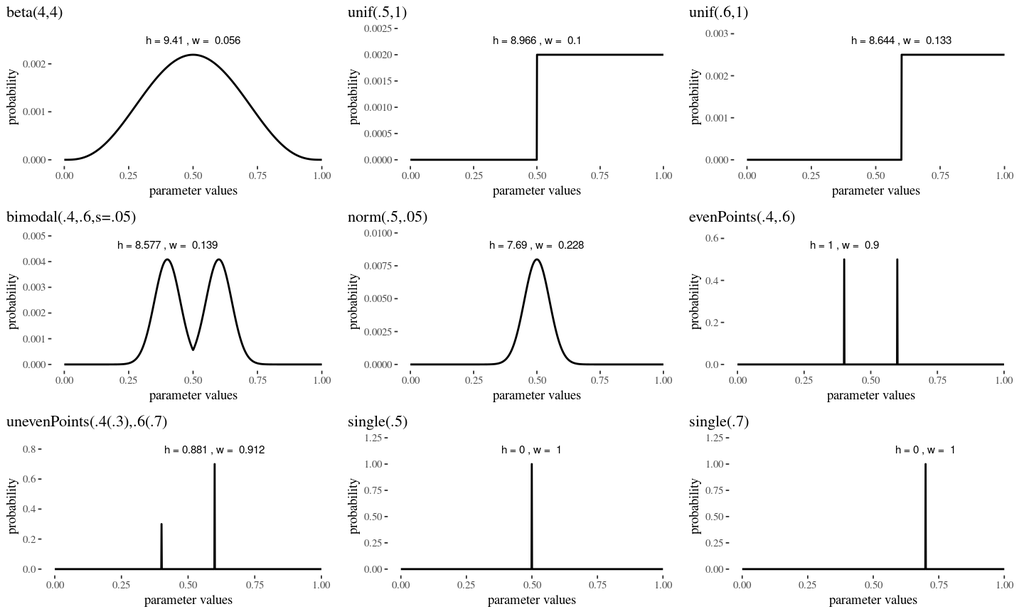

## Abuse and rocking example

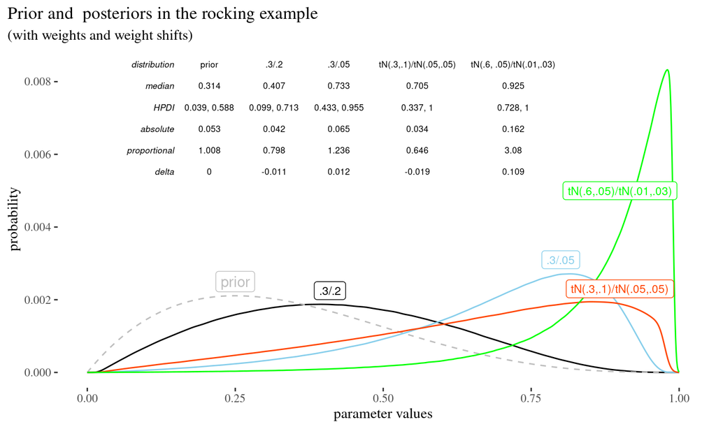

## Weights in BNs

[figure not shown]

## Weights in BNs

[figure not shown]

## Weights in BNs

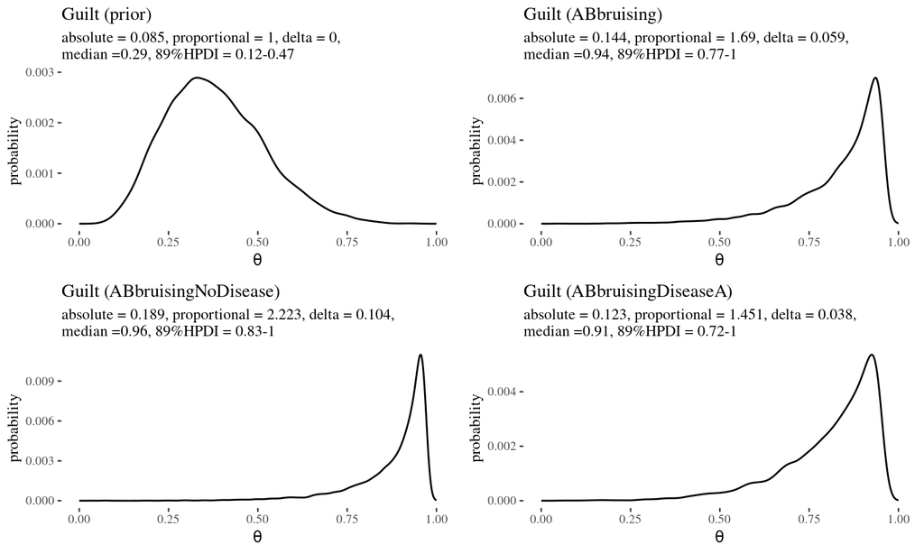

## Expected weight

[figure not shown]

## Wrapping up

The higher-order approach

- Leads to more honesty in uncertainty assessment
- Is more sensible than sensitivity analysis
- Integrates with Bayesian data analysis
- Leads to an information-theoretic account of evidential weight
- Is computationally feasible

## Other things I wish I had time to discuss

- connections with precise vs. imprecise probabilism in formal epistemology
- problems with existing opinion aggregation methods and a higher-order approach
- modeling synergy of multiple sources of information
- further properties of weight
- relation to evidential completeness